# Machine Learning - Intro

Carlos Grande Nuñez, Veronica Gomez Gomez y Pablo Olmos Martinez

13/02/2020

## Introduccion

Para esta practica sobre Machine Learning hemos continuado con nuestros datos de pisos. Debido a las caracteristicas especiales se nos hacia muy goloso comprobar que sistema funcionaria mejor a la hora de clasificar pisos caros.

Nos hemos puesto en la piel de supuestos clientes, para este caso en particular inmobiliarias de lujo, que desean hacer una correcta estimacion de si un piso que desean adquirir o vender entra en la clasificacion de piso de lujo.

```r
summary(df_cluster)
```

```
##       X.2             X.1              X                  Y
##  Min.   :    1   Min.   :    1   Min.   :-30.6010   Min.   :-28.84906
##  1st Qu.: 5400   1st Qu.: 5400   1st Qu.: -7.3212   1st Qu.:-12.29488
##  Median :10799   Median :10799   Median :  0.2695   Median :  0.09209
##  Mean   :10799   Mean   :10799   Mean   :  0.0000   Mean   :  0.00000
##  3rd Qu.:16198   3rd Qu.:16198   3rd Qu.:  8.5906   3rd Qu.: 11.16195
##  Max.   :21597   Max.   :21597   Max.   : 27.5371   Max.   : 30.13228
##
##        id                   date           price            bedrooms
##  Min.   :1.000e+06   6/23/2014:  142   Min.   :  78000   Min.   : 1.000
##  1st Qu.:2.123e+09   6/25/2014:  131   1st Qu.: 322000   1st Qu.: 3.000
##  Median :3.905e+09   6/26/2014:  131   Median : 450000   Median : 3.000
##  Mean   :4.580e+09   7/8/2014 :  127   Mean   : 540297   Mean   : 3.373
##  3rd Qu.:7.309e+09   4/27/2015:  126   3rd Qu.: 645000   3rd Qu.: 4.000
##  Max.   :9.900e+09   3/25/2015:  123   Max.   :7700000   Max.   :33.000
##                      (Other)  :20817
##    bathrooms      sqft_living       sqft_lot           floors
##  Min.   :0.500   Min.   :  370   Min.   :    520   Min.   :1.000
##  1st Qu.:1.750   1st Qu.: 1430   1st Qu.:   5040   1st Qu.:1.000
##  Median :2.250   Median : 1910   Median :   7618   Median :1.500
##  Mean   :2.116   Mean   : 2080   Mean   :  15099   Mean   :1.494
##  3rd Qu.:2.500   3rd Qu.: 2550   3rd Qu.:  10685   3rd Qu.:2.000
##  Max.   :8.000   Max.   :13540   Max.   :1651359   Max.   :3.500
##
##    waterfront            view          condition        grade
##  Min.   :0.000000   Min.   :0.0000   Min.   :1.00   Min.   : 3.000
##  1st Qu.:0.000000   1st Qu.:0.0000   1st Qu.:3.00   1st Qu.: 7.000
##  Median :0.000000   Median :0.0000   Median :3.00   Median : 7.000
##  Mean   :0.007547   Mean   :0.2343   Mean   :3.41   Mean   : 7.658
##  3rd Qu.:0.000000   3rd Qu.:0.0000   3rd Qu.:4.00   3rd Qu.: 8.000
##  Max.   :1.000000   Max.   :4.0000   Max.   :5.00   Max.   :13.000
##
##    sqft_above   sqft_basement       yr_built     yr_renovated
##  Min.   : 370   Min.   :   0.0   Min.   :1900   Min.   :   0.00
##  1st Qu.:1190   1st Qu.:   0.0   1st Qu.:1951   1st Qu.:   0.00
##  Median :1560   Median :   0.0   Median :1975   Median :   0.00
##  Mean   :1789   Mean   : 291.7   Mean   :1971   Mean   :  84.46
##  3rd Qu.:2210   3rd Qu.: 560.0   3rd Qu.:1997   3rd Qu.:   0.00
##  Max.   :9410   Max.   :4820.0   Max.   :2015   Max.   :2015.00
##
##     zipcode           lat             long        sqft_living15
##  Min.   :98001   Min.   :47.16   Min.   :-122.5   Min.   : 399
##  1st Qu.:98033   1st Qu.:47.47   1st Qu.:-122.3   1st Qu.:1490
##  Median :98065   Median :47.57   Median :-122.2   Median :1840
##  Mean   :98078   Mean   :47.56   Mean   :-122.2   Mean   :1987
##  3rd Qu.:98118   3rd Qu.:47.68   3rd Qu.:-122.1   3rd Qu.:2360
##  Max.   :98199   Max.   :47.78   Max.   :-121.3   Max.   :6210
##
##    sqft_lot15        cluster          hclust      Cluster_final
##  Min.   :   651   Min.   :1.000   Min.   :1.000   low:9970
##  1st Qu.:  5100   1st Qu.:1.000   1st Qu.:2.000   med:8225
##  Median :  7620   Median :2.000   Median :5.000   top:3402
##  Mean   : 12758   Mean   :2.065   Mean   :4.829
##  3rd Qu.: 10083   3rd Qu.:3.000   3rd Qu.:8.000
##  Max.   :871200   Max.   :3.000   Max.   :9.000
##
```

## Mapa de los pisos

Uno de los detalles importantes consiste en ver como se distribuyen los pisos en la zona:

[output not shown]

[interactive chart not shown]

Como podemos observar la cantidad de pisos que se han estado a la venta es muy alta. De todo esto nos surgen las siguientes preguntas:

- ¿Cuales de ellos merecen la pena?
- ¿Estamos intentando comprarlo a sobreprecio?
- ¿Estan mis vendedores intentando venderlo con una tasacion baja para conseguir una ganga y a continuacion hacer negocio en alguna plataforma como AirBnb a mi costa?

Nuestra solucion intenta responder a estas preguntas mediante machine learning. A continuacion aplicaremos distintas soluciones para dar con la mas adecuada al problema que se nos plantea.

Como nuestra solucion analizara al final sobre los precios de los pisos, conviene ver por encima antes dicha variable.

## Variable precio

```r
#Obtención de variables cuantitativas
df_cuantitativas = df_cluster %>% select(3, 6, 7, 13:16, 18:dim(df_cluster)[2])

data.frame(variable = names(df_cuantitativas),
           classe = sapply(df_cuantitativas, typeof),
           first_values = sapply(df_cuantitativas, function(x) paste0(head(x),  collapse = ", ")),
           row.names = NULL) %>% kable() %>% kable_styling()
```

| variable | classe | first_values |
| --- | --- | --- |
| X | double | 3.7621642125675, -24.0359753189715, 5.21701533117796, 7.58872965013843, 0.666181472085254, -2.65425155380627 |
| date | integer | 10/13/2014, 12/9/2014, 2/25/2015, 12/9/2014, 2/18/2015, 5/12/2014 |
| price | double | 221900, 538000, 180000, 604000, 510000, 1230000 |
| waterfront | integer | 0, 0, 0, 0, 0, 0 |
| view | integer | 0, 0, 0, 0, 0, 0 |
| condition | integer | 3, 3, 3, 5, 3, 3 |
| grade | integer | 7, 7, 6, 7, 8, 11 |
| sqft_basement | integer | 0, 400, 0, 910, 0, 1530 |
| yr_built | integer | 1955, 1951, 1933, 1965, 1987, 2001 |
| yr_renovated | integer | 0, 1991, 0, 0, 0, 0 |
| zipcode | integer | 98178, 98125, 98028, 98136, 98074, 98053 |
| lat | double | 47.5112, 47.721, 47.7379, 47.5208, 47.6168, 47.6561 |
| long | double | -122.257, -122.319, -122.233, -122.393, -122.045, -122.005 |
| sqft_living15 | integer | 1340, 1690, 2720, 1360, 1800, 4760 |
| sqft_lot15 | integer | 5650, 7639, 8062, 5000, 7503, 101930 |
| cluster | integer | 1, 1, 1, 2, 3, 3 |
| hclust | integer | 1, 2, 3, 1, 3, 4 |
| Cluster_final | integer | low, top, med, low, med, med |

```r
var_price = df_cuantitativas$price
name = "price"

phist <- function(df, bns = 50, varname) {
  p = ggplot(df, aes(x = df[[varname]])) +
    geom_histogram(aes(y =..density..),
                   colour = "#464159",
                   fill = "#8bbabb", na.rm = TRUE) +
    ggtitle("Diagrama Boxplot") +
    ylab("Densidad") + xlab(varname) +
    scale_x_continuous(labels = scales::comma) +
  stat_function(fun = dnorm, args = list(mean = mean(df[[varname]]), sd = sd(df[[varname]])))
return(p)
}

pbox <- function(col, varname){
p = qplot('1', col, geom="boxplot") +
  geom_boxplot(fill='#8bbabb', color="#464159") +
  ggtitle("Diagrama Boxplot") + ylab("Valores") + xlab(varname)
return(p)
}
# Descripción de la variable
describe(var_price)
```

```
## var_price
##        n  missing distinct     Info     Mean      Gmd      .05      .10
##    21597        0     3622        1   540297   329526   210000   245000
##      .25      .50      .75      .90      .95
##   322000   450000   645000   887000  1160000
##
## lowest :   78000   80000   81000   82000   82500
## highest: 5350000 5570000 6890000 7060000 7700000
```

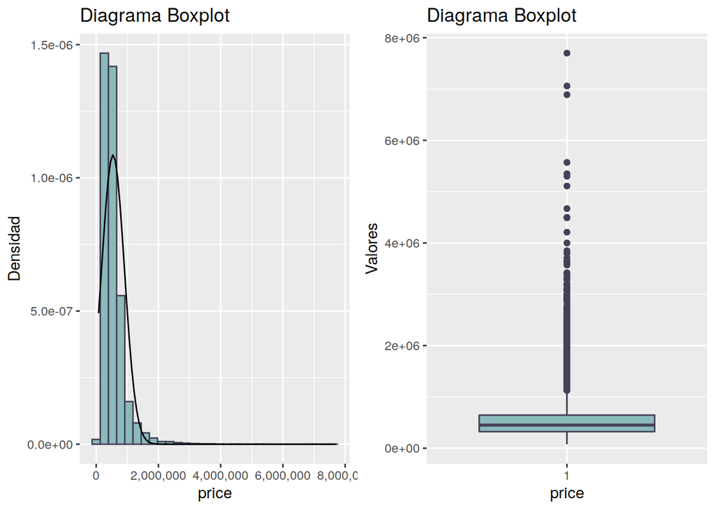

```r
# Visualización de la variable
p1 <- phist(df_cuantitativas, ., name)
p2 <- pbox(var_price, name)
grid.arrange(p1, p2, nrow=1)
```

Como se observa no esta muy claro, a continuacion se crearan clusters en funcion de los precios para poder enseñar a los distintos modelos de Machine Learning aplicados. Al final se analizara cual de los modelos es el mas exacto.